# CNK 07 - deeper analysis

D. Bottoli, M. Mlynarczyk, J. Trojgo, A. Sitko

### Station description

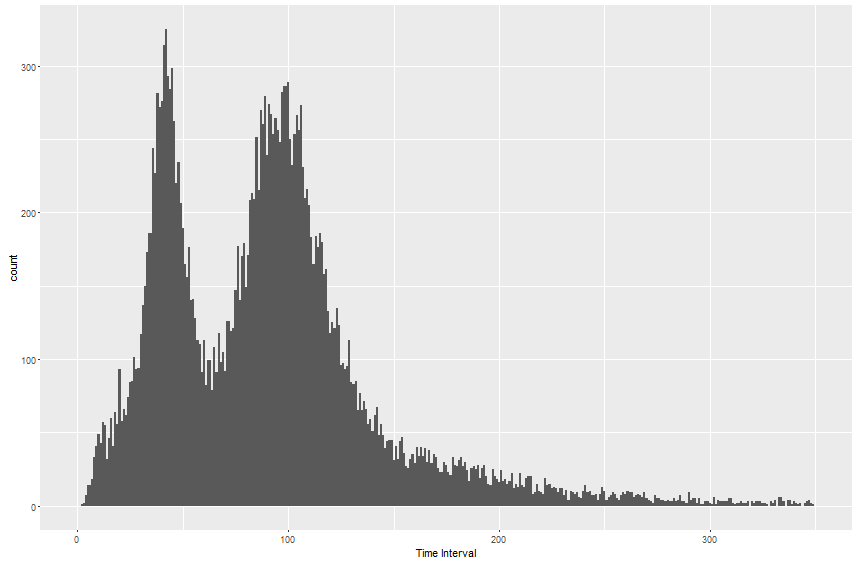

### Station description

Station **CNK07** consist of an experiment based on **Stroop effect**.

This effect is shown through a psychological experiment on **two different levels**.

In the first one, the user is asked to press a button of the *same colour* as the word that he is reading.

But what if the word and its colour are *dissociated*?

This happens on the second level: the user has to follow the same procedure but this time it’s much harder.

### Stroop effect

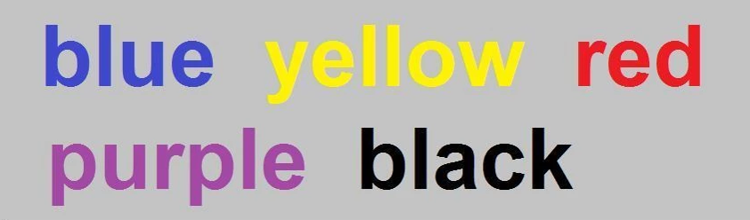

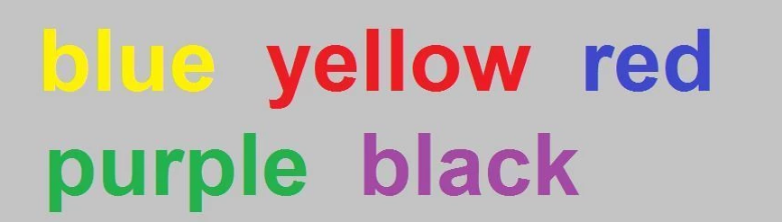

### Deeper analysis - agenda

1. CNK07 descriptors - mixtures of distributions parameters.
2. Stroop effect - is it proven by the data?

### Clusters - previous approach

Below there are presented clusters obtained *in the second phase*. They are constructed basing on scenes counts vectors.

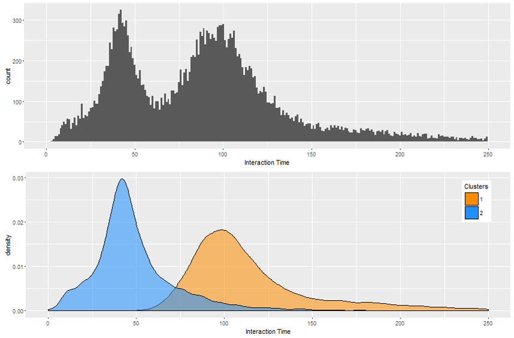

### Clusters - EM algorithm

How many clusters should we look for?

Let's start with the previous approach - **two clusters**.

### Clusters - EM algorithm - two clusters

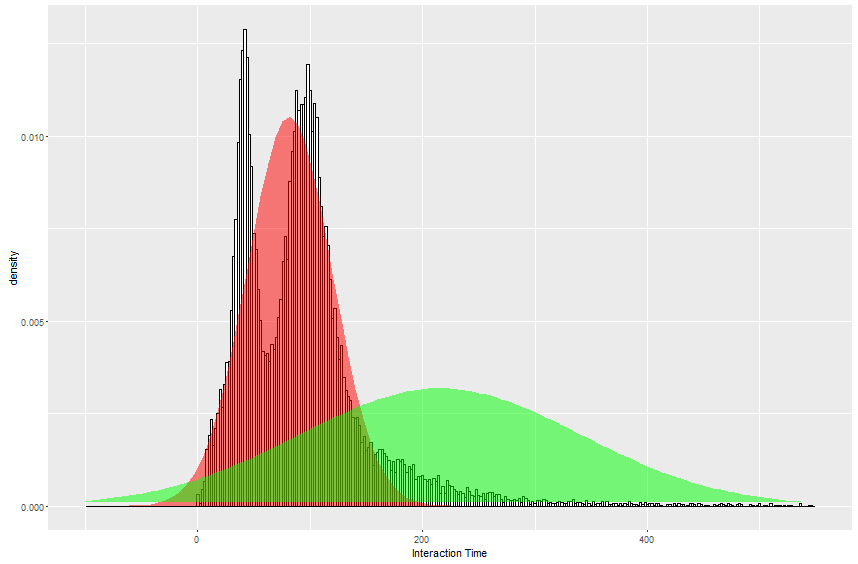

### Clusters - EM algorithm

**Note:** It doesn't look good… Maybe there are more than two clusters?

Let's train EM algorithm using different numbers of components and see which one *minimizes BIC*.

We will train two different models:

- “E” with equal variances,
- “V” with different variances.

### Clusters - EM algorithm - BIC analysis

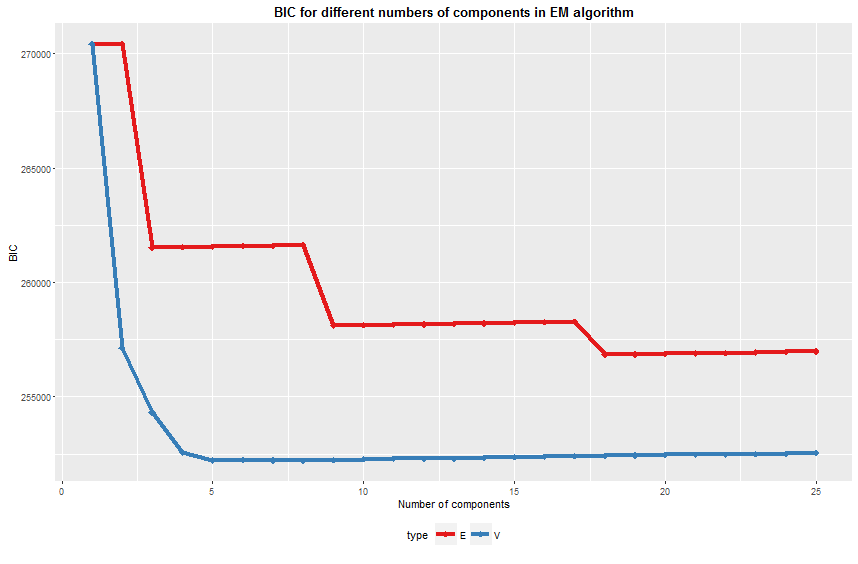

### Clusters - EM algorithm - BIC analysis

**Note:** Models with different variances outperform models with equal variance.  
It looks like adding just the first few clusters improves BIC significantly.

### Clusters - EM algorithm - BIC analysis

We performed *Bootstrap Likelihood Ratio Test for the Number of Mixture Components* to identify the most satisfying number of clusters.  
It turned out that this is **five**.

### Clusters - EM algorithm - final results

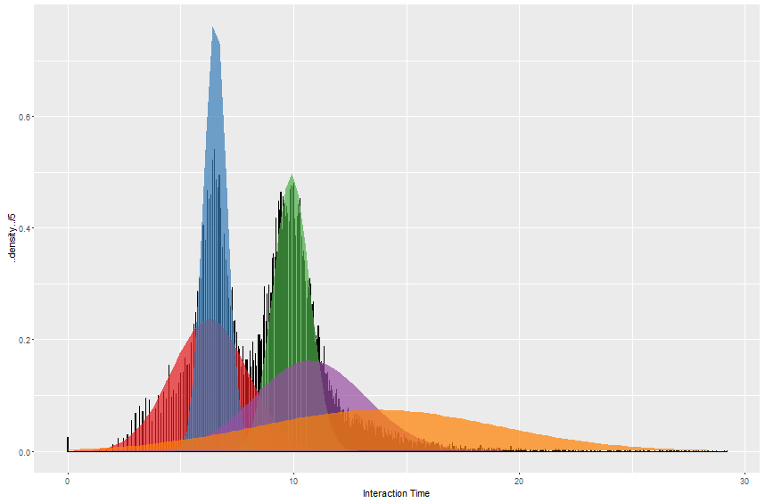

### Clusters - EM algorithm - final results

|  | red cluster | blue cluster | green cluster | violet cluster | orange cluster |
| --- | --- | --- | --- | --- | --- |
| Splash | 100% | 100% | 100% | 100% | 100% |
| LevelOne | 100% | 100% | 100% | 100% | 100% |
| ResultOne | 82% | 40% | 98% | 100% | 99% |
| LevelTwo | 8% | 7% | 92% | 96% | 91,7% |
| ResultTwo | 0,3% | 0,8% | 84% | 94% | 86% |
| StroopHighScore | 0,1% | 0,2% | 38% | 59% | 51% |

### Clusters - EM algorithm - final results

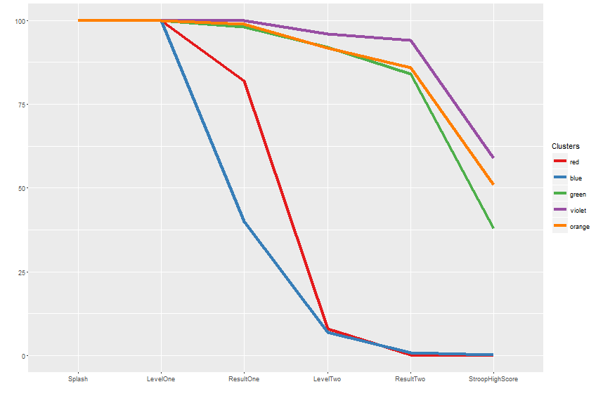

### Clusters - EM algorithm - final results

|  | red | blue | green | violet | orange |
| --- | --- | --- | --- | --- | --- |
| Average time spent at one stations (sec) | 65 | 60 | 89 | 110 | 110 |
| Average time spent at CNK07 (sec) | 44 | 33 | 96 | 178 | 178 |
| Average time spent at Whole Sector (min) | 42 | 40 | 51 | 51 | 53 |
| Avarege number of visited stations | 11 | 10 | 13 | 13 | 13 |

### Clusters - EM algorithm - final results

Below we present the amounts of visitors in each cluster.

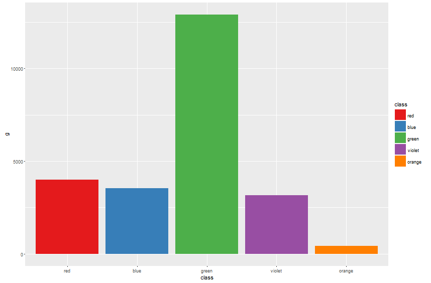

| 1 | 2 | 3 | 4 | 5 |
| --- | --- | --- | --- | --- |
| 4002 | 3550 | 12909 | 3171 | 423 |

### Stroop effect - is it proven by the data?

SECOND OBSERVATION:

- Frequencies of games per person divided into two levels are presented on the rigth,
- We don't observe it from the table but some users played level one 27, 30 and 34 times.

**Level One**

|  | Freq. | Relative Freq. |
| --- | --- | --- |
| 1 | 20130 | 82.7% |
| 2 | 3364 | 13.8% |
| 3 | 598 | 2.5% |
| 4+ | 245 | 1.0% |

**Level Two**

|  | Freq. | Relative Freq. |
| --- | --- | --- |
| 1 | 13799 | 86.0% |
| 2 | 1913 | 11.9% |
| 3 | 241 | 1.5% |
| 4+ | 91 | 0.6% |

### Stroop effect - is it proven by the data?

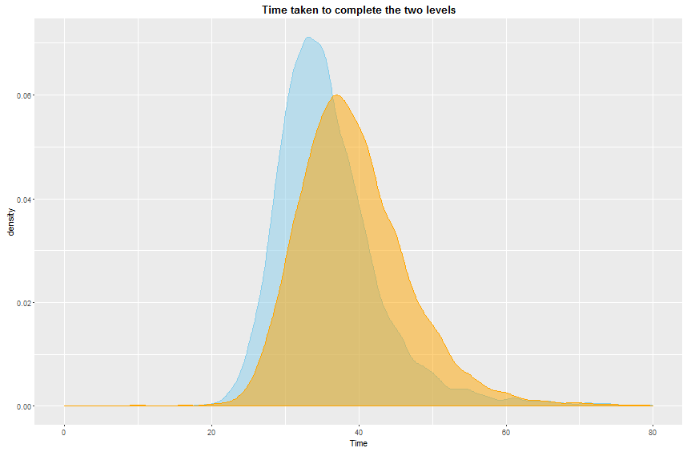

### Stroop effect - is it proven by the data?

THIRD OBSERVATON:

- From the plot we can observe that distributions are bell-shaped, we could consider them **normal curves with different means**,
- **72.7%** of analysed people completed the first level faster.

  |  | 1st Q. | Median | Mean | 3rd Q. |
  | --- | --- | --- | --- | --- |
  | Level One | 31 | 35 | 36.18 | 39 |
  | Level Two | 34 | 38 | 39.41 | 44 |

### Stroop effect - is it proven by the data?

RESULTS:

- Kolmogorov-Smirnov test **rejects the hypothesis about distributions equality**!
- ANOVA **rejects the hypothesis about means equality**!

CONCLUSION:

- From our analysis we can confirm, with a high level of confidence, that the Stoop Effect is present in people.

Finito! Thank you!